# 431 Class 25

Thomas E. Love, Ph.D.

2025-12-04

## Today’s Agenda

1. Graphical and Numerical Summaries of Data
2. 432 preview: A `tidymodels` example with interaction
3. Takeaways from 431

## Today’s Packages

```r
library(janitor)
library(mosaic)
library(patchwork)
library(broom)

library(tidyverse)

theme_set(theme_bw())
```

and a couple of secrets, hidden for now.

# Visualizing Data

## New Data Set 1

```
  response   n missing     mean       sd
1        y 142       0 47.83472 26.93974
2        x 142       0 54.26610 16.76982
```

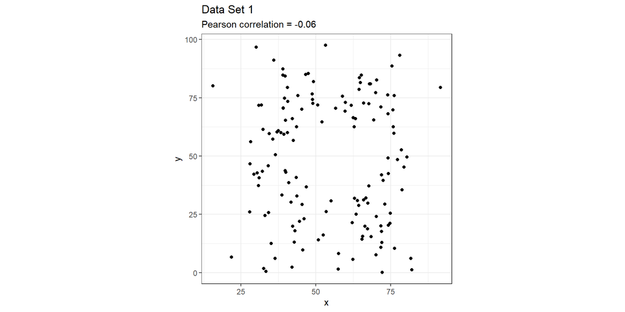

## 13 Data Sets in the `df` tibble:

```
   set   n mean_x  sd_x mean_y  sd_y corr_xy
1    1 142  54.27 16.77  47.83 26.94   -0.06
2    2 142  54.27 16.77  47.83 26.94   -0.07
3    3 142  54.27 16.76  47.84 26.93   -0.07
4    4 142  54.26 16.77  47.83 26.94   -0.06
5    5 142  54.26 16.77  47.84 26.93   -0.06
6    6 142  54.26 16.77  47.83 26.94   -0.06
7    7 142  54.27 16.77  47.84 26.94   -0.07
8    8 142  54.27 16.77  47.84 26.94   -0.07
9    9 142  54.27 16.77  47.83 26.94   -0.07
10  10 142  54.27 16.77  47.84 26.93   -0.06
11  11 142  54.27 16.77  47.84 26.94   -0.07
12  12 142  54.27 16.77  47.83 26.94   -0.07
13  13 142  54.26 16.77  47.84 26.93   -0.07
```

## New Data: Model for Set 1

```r
set_1 <- lm(y ~ x, data = df |> filter(set == 1))

tidy(set_1, conf.int = T, conf.level = 0.9) |>
  select(-statistic, -p.value)
```

```
# A tibble: 2 × 5
  term        estimate std.error conf.low conf.high
  <chr>          <dbl>     <dbl>    <dbl>     <dbl>
1 (Intercept)   53.4       7.69    40.7      66.2
2 x             -0.103     0.135   -0.327     0.121
```

```r
glance(set_1) |>
  select(r.squared, adj.r.squared, sigma, BIC, p.value)
```

```
# A tibble: 1 × 5
  r.squared adj.r.squared sigma   BIC p.value
      <dbl>         <dbl> <dbl> <dbl>   <dbl>
1   0.00411      -0.00300  27.0 1352.   0.448
```

## All 13 Models, at a glance

```
# A tibble: 13 × 6
   dataset r.squared adj.r.squared sigma   AIC   BIC
     <dbl>     <dbl>         <dbl> <dbl> <dbl> <dbl>
 1       1   0.00411      -0.00300  27.0 1343. 1352.
 2       2   0.00470      -0.00241  27.0 1343. 1352.
 3       3   0.00467      -0.00244  27.0 1343. 1351.
 4       4   0.00416      -0.00296  27.0 1343. 1352.
 5       5   0.00364      -0.00348  27.0 1343. 1352.
 6       6   0.00381      -0.00331  27.0 1343. 1352.
 7       7   0.00469      -0.00242  27.0 1343. 1352.
 8       8   0.00476      -0.00235  27.0 1343. 1352.
 9       9   0.00471      -0.00240  27.0 1343. 1352.
10      10   0.00396      -0.00315  27.0 1343. 1352.
11      11   0.00482      -0.00229  27.0 1343. 1352.
12      12   0.00443      -0.00268  27.0 1343. 1352.
13      13   0.00430      -0.00281  27.0 1343. 1352.
```

## Plot for Data Set 1

Does a linear model for y using x seem appropriate?

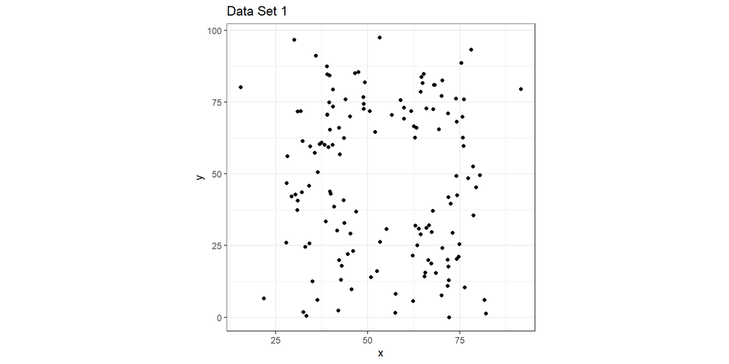

## https://xkcd.com/1725/

[figure not shown]

## Set 1 Plot (+lm, +loess)

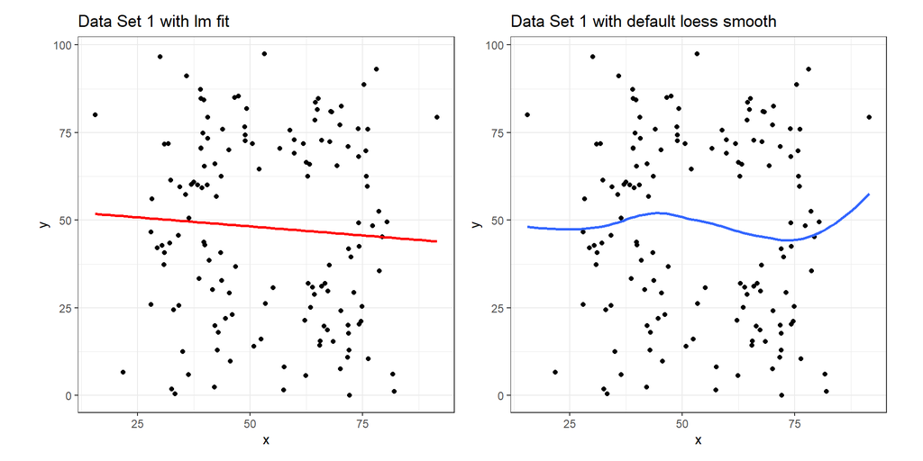

### Model 1 (linear model for Set 1)

```
Call:
lm(formula = y ~ x, data = filter(df, set == 1))

Coefficients:
(Intercept)            x
     53.425       -0.103
```

## The Other 12 Data Sets

Models 2-13 all look about the same in terms of means, medians, correlations, regression models, but what happens if we plot the data?

```r
temp2 <- df |> filter(set != 1)

ggplot(temp2, aes(x = x, y = y, color = dataset)) +
  geom_point(show.legend = FALSE) +
  facet_wrap(~ set, labeller = "label_both")
```

## The Other 12 Data Sets

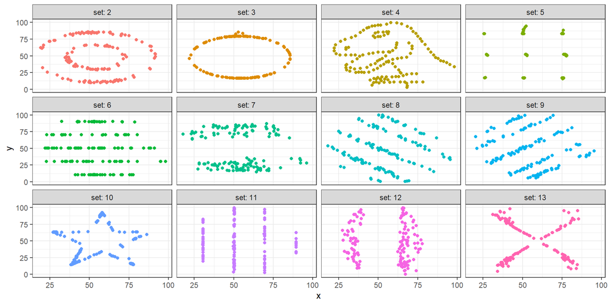

## Actually, each set has a name

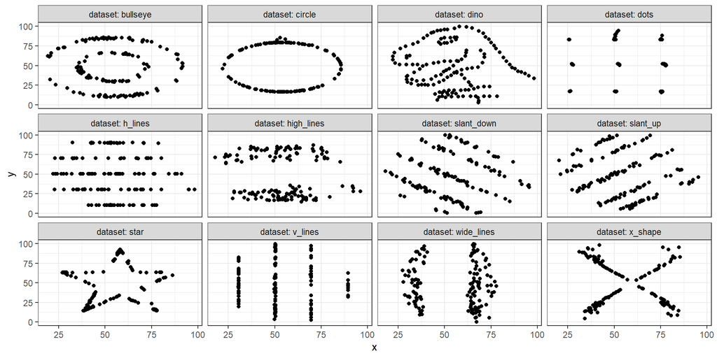

## Same linear fit, each time

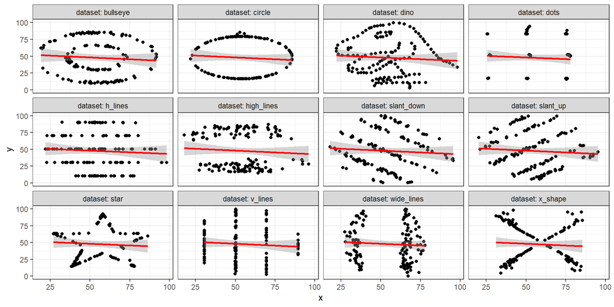

## loess smooths?

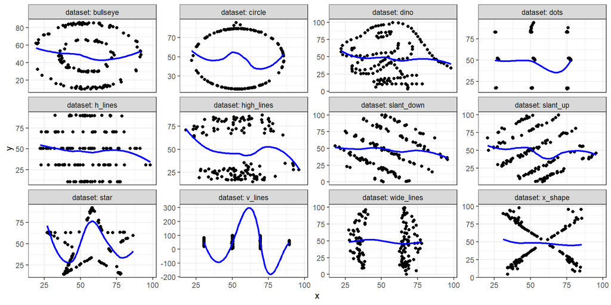

## And the data come from

These are, of course, the datasauRus dozen data sets described in Spiegelhalter, available in the `datasauRus` package, which you can install from CRAN, thanks to the work of Steph Locke.

```
library(datasauRus)
df <- datasaurus_dozen
```

- These were created by Alberto Cairo, who has some great books like *How Charts Lie*

The moral of the story: **Never trust summary statistics alone, always visualize your data**

## Two Cool Things, available online…

1. We’ll visit Tomas Westlake’s work at https://r-mageddon.netlify.app/post/reanimating-the-datasaurus/

```r
library(datasauRus)
library(ggplot2)
library(gganimate)

ggplot(datasaurus_dozen, aes(x=x, y=y))+
  geom_point()+
  theme_minimal() +
  transition_states(dataset, 3, 1)
```

## Two Cool Things, available online…

2. Next, we’ll visit https://www.autodesk.com/research/publications/same-stats-different-graphs

This is Same Stats, Different Graphs: Generating Datasets with Varied Appearance and Identical Statistics through Simulated Annealing by Justin Matejka and George Fitzmaurice.

We’ll look at a couple of the animated plots they generate there.

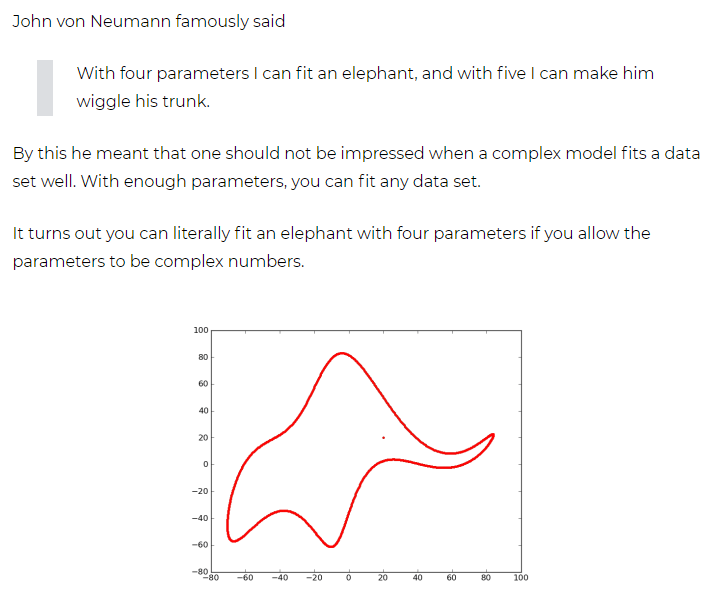

# A Taste of 432: Sea Urchins and Tidy Modeling

[figure not shown]

## Sea Urchins and Tidy Modeling

Constable (1993) compared the inter-radial suture widths of urchins maintained on one of three food regimes

- Initial: no additional food supplied above what was in the initial sample
- Low: food supplied periodically
- High: food supplied ad libitum (as often as desired)

In an attempt to control for substantial variability in urchin sizes, the initial body volume of each urchin was measured as a covariate.

- This example comes from https://www.tidymodels.org/start/models/
- Another key source is https://www.flutterbys.com.au/stats/tut/tut7.5a.html
- Data from Constable, A.J. The role of sutures in shrinking of the test in Heliocidaris erythrogramma (Echinoidea: Echinometridae). *Marine Biology* 117, 423-430 (1993). https://doi.org/10.1007/BF00349318

## Package Load / Data ingest (Sea Urchins)

```r
library(tidymodels)
library(broom.mixed)

urchins <-
  # Data were assembled for a tutorial
  # at https://www.flutterbys.com.au/stats/tut/tut7.5a.html
  read_csv("https://tidymodels.org/start/models/urchins.csv") |>
  # Change the names to be a little more verbose
  setNames(c("food_regime", "initial_volume", "width")) |>
  mutate(food_regime =
           factor(food_regime,
                  levels = c("Initial", "Low", "High")))
```

## The `urchins` data

For each of 72 sea urchins, we know their

- experimental feeding regime group (`food_regime`: either Initial, Low, or High),
- size in milliliters at the start of the experiment (`initial_volume`), and
- suture width at the end of the experiment (`width`).

```r
glimpse(urchins)
```

```
Rows: 72
Columns: 3
$ food_regime    <fct> Initial, Initial, Initial, Initial, Initial, Initial, I…
$ initial_volume <dbl> 3.5, 5.0, 8.0, 10.0, 13.0, 13.0, 15.0, 15.0, 16.0, 17.0…
$ width          <dbl> 0.010, 0.020, 0.061, 0.051, 0.041, 0.061, 0.041, 0.071,…
```

## Plot the Data

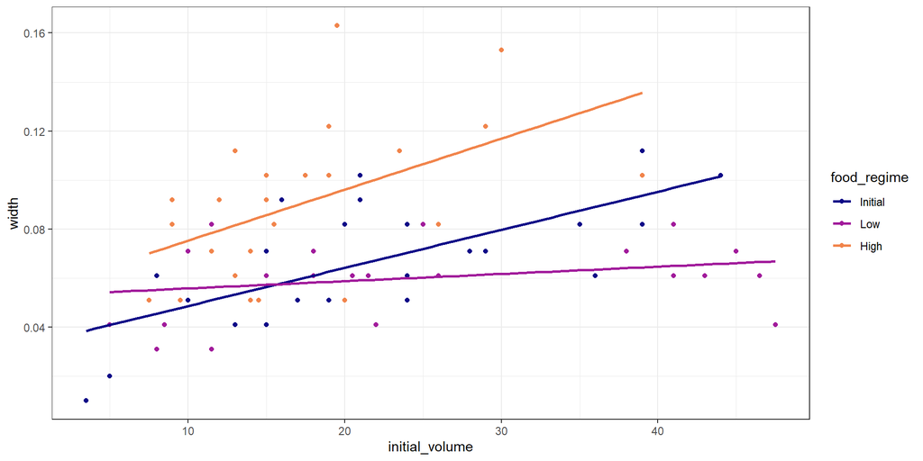

## How should we model the data?

Slopes appear to be different for at least two of the feeding regimes, so we’ll use a linear model with interaction to allow each food regime to have a different slope and intercept for the effect of initial volume.

```r
lm(width ~ initial_volume * food_regime, data = urchins) |> tidy() |>
  select(term, estimate)
```

```
# A tibble: 6 × 2
  term                            estimate
  <chr>                              <dbl>
1 (Intercept)                     0.0331
2 initial_volume                  0.00155
3 food_regimeLow                  0.0198
4 food_regimeHigh                 0.0214
5 initial_volume:food_regimeLow  -0.00126
6 initial_volume:food_regimeHigh  0.000525
```

## Setting up a linear regression with `tidymodels`

```r
lm_mod <-
  linear_reg()  |>
  set_engine("lm")

lm_mod
```

```
Linear Regression Model Specification (regression)

Computational engine: lm
```

It turns out that we’ll have several options for engines here.

## We can estimate or train the model with `fit()`

```r
lm_fit <-
  lm_mod |>
  fit(width ~ initial_volume * food_regime, data = urchins)
```

We’ll look at the results on the next slide.

## What’s in `lm_fit`?

```r
tidy(lm_fit, conf.int = TRUE) |> select(term, estimate, conf.low, conf.high)
```

```
# A tibble: 6 × 4
  term                            estimate  conf.low conf.high
  <chr>                              <dbl>     <dbl>     <dbl>
1 (Intercept)                     0.0331    0.0139    0.0523
2 initial_volume                  0.00155   0.000760  0.00235
3 food_regimeLow                  0.0198   -0.00615   0.0457
4 food_regimeHigh                 0.0214   -0.00760   0.0504
5 initial_volume:food_regimeLow  -0.00126  -0.00228  -0.000241
6 initial_volume:food_regimeHigh  0.000525 -0.000876  0.00193
```

## Make Predictions

Suppose that, for a publication, it would be particularly interesting to make a plot of the mean body size for urchins that started the experiment with an initial volume of 20ml. To create such a graph, we start with some new example data that we will make predictions for.

```r
new_points <- expand.grid(initial_volume = 20,
                          food_regime = c("Initial", "Low", "High"))

new_points
```

```
  initial_volume food_regime
1             20     Initial
2             20         Low
3             20        High
```

## Obtain Predicted Results for these `new_points`

We’ll develop mean predictions and uncertainty intervals.

```r
mean_pred <- predict(lm_fit, new_data = new_points)
conf_int_pred <- predict(lm_fit,
                         new_data = new_points,
                         type = "conf_int")
plot_data <-
  new_points |>
  bind_cols(mean_pred) |>
  bind_cols(conf_int_pred)
```

## Plot the `plot_data` results

```r
ggplot(plot_data, aes(x = food_regime, y = .pred)) +
  geom_point() +
  geom_errorbar(aes(ymin = .pred_lower,
                    ymax = .pred_upper),
                width = .2) +
  labs(y = "urchin size",
       title = "Linear model fit using `lm`")
```

## Plot the `plot_data` results

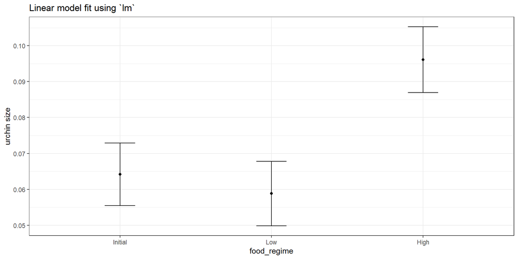

## Could we use Bayesian methods?

Would the results be different if we used a Bayesian approach?

- Need to select a prior.
- Let’s use bell-shaped priors on the intercepts and slopes, using a Cauchy distribution (works out to be the same as a t distribution with one degree of freedom)
- The `stan_glm()` function can be used, and this is available as an engine in `tidymodels`, where we need to specify `prior` and `prior_intercept` to fit a linear model.

## Setting up a Bayesian Model

```r
prior_dist <- rstanarm::student_t(df = 1)

set.seed(123)

bayes_mod <-
  linear_reg() |>
  set_engine("stan",
             prior_intercept = prior_dist,
             prior = prior_dist)
```

## Training the Bayes Model

```r
bayes_fit <- bayes_mod |>
  fit(width ~ initial_volume * food_regime, data = urchins)

tidy(bayes_fit, conf.int = TRUE) |>
  select(term, estimate, conf.low, conf.high)
```

```
# A tibble: 6 × 4
  term                            estimate  conf.low conf.high
  <chr>                              <dbl>     <dbl>     <dbl>
1 (Intercept)                     0.0329    0.0173    0.0487
2 initial_volume                  0.00156   0.000903  0.00222
3 food_regimeLow                  0.0198   -0.00171   0.0411
4 food_regimeHigh                 0.0215   -0.00253   0.0441
5 initial_volume:food_regimeLow  -0.00126  -0.00209  -0.000423
6 initial_volume:food_regimeHigh  0.000522 -0.000606  0.00165
```

## Building the plot for the Bayes model

```r
bayes_plot_data <-
  new_points |>
  bind_cols(predict(bayes_fit, new_data = new_points)) |>
  bind_cols(predict(bayes_fit, new_data = new_points,
                    type = "conf_int"))

ggplot(bayes_plot_data, aes(x = food_regime, y = .pred)) +
  geom_point() +
  geom_errorbar(aes(ymin = .pred_lower, ymax = .pred_upper),
                width = .2) +
  labs(y = "urchin size",
       title = "Bayesian model with t(1) prior distribution")
```

## Building the plot for the Bayes model

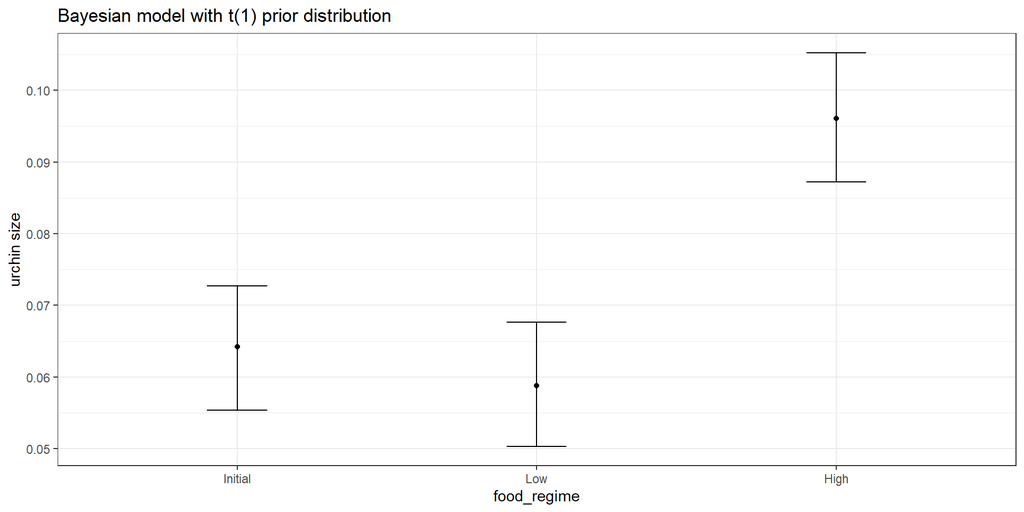

## Comparing the Models

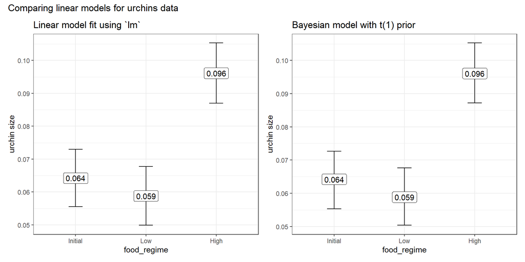

## The models aren’t actually the same

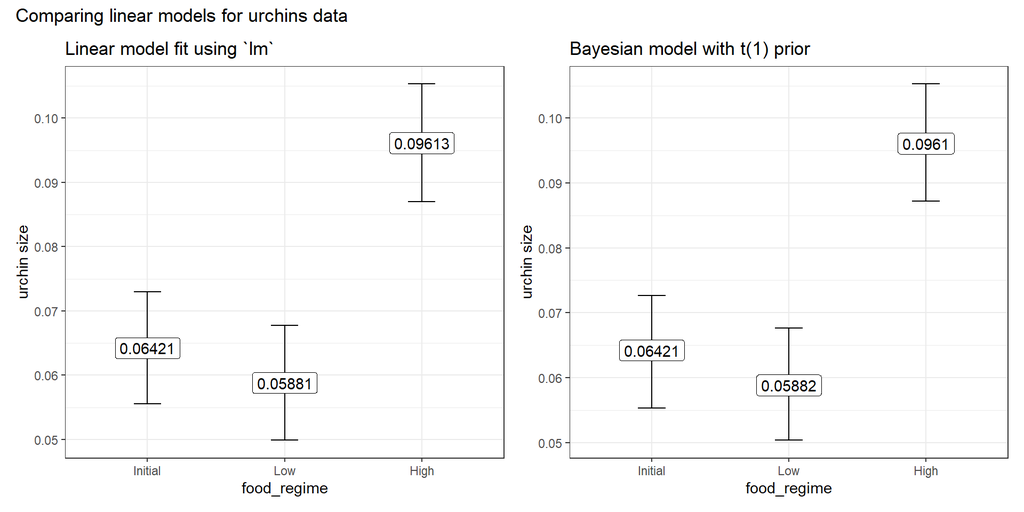

## What are we plotting, actually?

```r
plot_data
```

```
  initial_volume food_regime      .pred .pred_lower .pred_upper
1             20     Initial 0.06421443  0.05549934  0.07292952
2             20         Low 0.05880940  0.04986251  0.06775629
3             20        High 0.09613343  0.08696233  0.10530453
```

```r
bayes_plot_data
```

```
  initial_volume food_regime      .pred .pred_lower .pred_upper
1             20     Initial 0.06420994  0.05533727  0.07267092
2             20         Low 0.05882441  0.05033710  0.06767421
3             20        High 0.09610333  0.08719659  0.10526191
```

# What do we take away from 431 at the end of the day?

## Ten Simple Rules for Effective Statistical Practice

From [PLoS Computational Biology](http://journals.plos.org/ploscompbiol/article?id=10.1371/journal.pcbi.1004961)

1. Statistical Methods Should Enable Data to Answer Scientific Questions
2. Signals Always Come with Noise
3. Plan Ahead, Really Ahead
4. Worry About Data Quality
5. Statistical Analysis Is More Than a Set of Computations

## Ten Simple Rules for Effective Statistical Practice

From [PLoS Computational Biology](http://journals.plos.org/ploscompbiol/article?id=10.1371/journal.pcbi.1004961)

6. Keep it Simple
7. Provide Assessments of Variability
8. Check Your Assumptions
9. When Possible, Replicate!
10. Make Your Analysis Reproducible

## The Impact of Study Design (Gelman)

Applied statistics is hard.

- Doing a statistical analysis is like playing basketball, or knitting a sweater. You can get better with practice.
- Incompetent statistics does not necessarily doom a research paper: some findings are solid enough that they show up even when there are mistakes in the data collection and data analyses. But we’ve also seen many examples where incompetent statistics led to conclusions that made no sense but still received publication and publicity.
- We should be thinking not just about data analysis, but also data quality.

> To consult the statistician after an experiment is finished is often merely to ask him to conduct a post mortem examination. He can perhaps say what the experiment died of. (R. A. Fisher)

## Build Tidy Data Sets

- Each variable should be in one column.
- Each observation should be in a different row.
- There should be one table for each “kind” of variable.
- If you have multiple tables, they should include a column in the table that allows them to be linked.
- Include real column names. `Age_at_Diagnosis` is **much** better than `ADx`.
- Build useful codebooks.

Jeff Leek: “[How to share data with a statistician](https://github.com/jtleek/datasharing)”

## A Tip from David Robinson

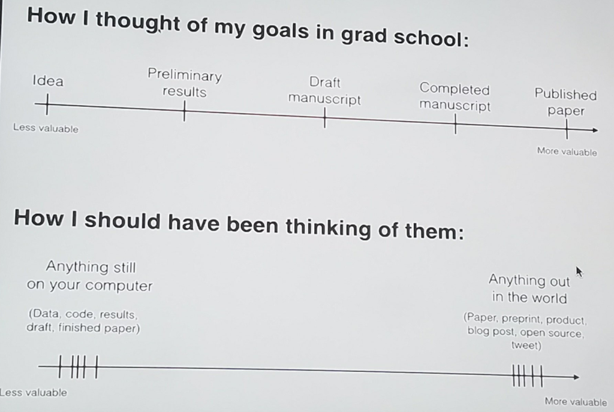

## Ten of the Most Important 431 Ideas

1. You have to visualize and count data to understand it.
2. 90% of statistical work could be described as data management.
3. Quarto and the tidyverse make it easier to do the right thing.
4. Statistical significance is not a helpful concept.
5. Point estimates and confidence intervals are useful ideas.

## Ten of the Most Important 431 Ideas

6. Most statistical procedures are in fact regression models.
7. All statistical methods involve assumptions worth checking.
8. The bootstrap is a very useful, and somewhat underused tool.
9. Prediction models need to predict well in new situations.
10. Statistical thinking is far too important to be left to statisticians.

[figure not shown]